# Exploring and Analyzing Netflix Show User Reviews

# Introduction

```r
library(tidyverse)
library(dplyr)
library(ggplot2)
library(scales)
library(lubridate)
```

# DataSet

Import the required Netflix Data set, which can be found [Here!](https://raw.githubusercontent.com/reisanar/datasets/master/netflixShows.csv)

```r
#read the processed Data
netflixshows  <- read.csv('netflix_titles.csv')

# Delete the description and Show ID Columns
netflixshows <- netflixshows%>%
  select(-description, -show_id, - cast)
```

# Data Exploration and Analysis

## Exploring Single Variable Attributes

### Content Type:

```r
#Because countries are sometimes grouped together, separating them is required.
sep_country_movie <- netflixshows%>%
  separate_rows(country, sep = ",")%>%
  group_by(country)%>%
  #Due to the size of the dataset, we had to filter out countries that had under 100 Movie entries
  filter(n()> 100 & type == "Movie")%>%
  summarize(country)
```

### Country of Origin:

This next visualization graphically demonstrates the distribution of content on Netflix per country. Content is separated by the Type of Content it is, either Movie or TV Show.

**Netflix Movie Content by Country**

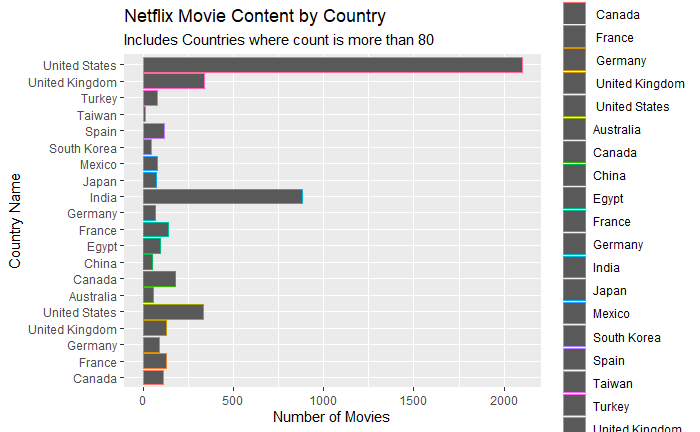

```r
#Because countries are sometimes grouped together, separating them is required.
  #Due to the size of the dataset, we had to filter out countries that had under 80 Movie entries.
netflixshows%>%
  separate_rows(country, sep = ",")%>%
  group_by(country)%>%
  filter(n()> 80 & type == "Movie" & country != "")%>%
  ggplot()+
    geom_bar(mapping = aes(
      y = country,
      color = country),
      na.rm = T)+
        labs(
          title = "Netflix Movie Content by Country",
          subtitle = "Includes Countries where count is more than 80",
          y = "Country Name",
          x = "Number of Movies"
        )
```

**Netflix TV Show Content by Country**

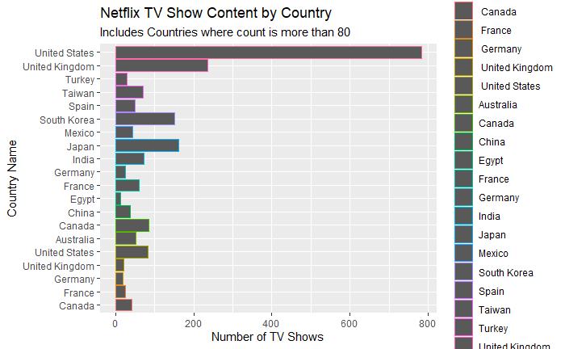

```r
netflixshows%>%
  separate_rows(country, sep = ",")%>%
  group_by(country)%>%
  filter(n()> 80 & type == "TV Show" & country != "")%>%
  ggplot()+
    geom_bar(mapping = aes(
      y = country,
      color = country),
      na.rm = T)+
        labs(
          title = "Netflix TV Show Content by Country",
          subtitle = "Includes Countries where count is more than 80",
          y = "Country Name",
          x = "Number of TV Shows",

        )
```

```r
NA
```

### Year of Release:

Netflix has a wide range of films on their platform. Below is a graphical representation of the distributions of content by original release date, separated by both Movies and TV Shows.

**Netflix Movie content by Release Year**

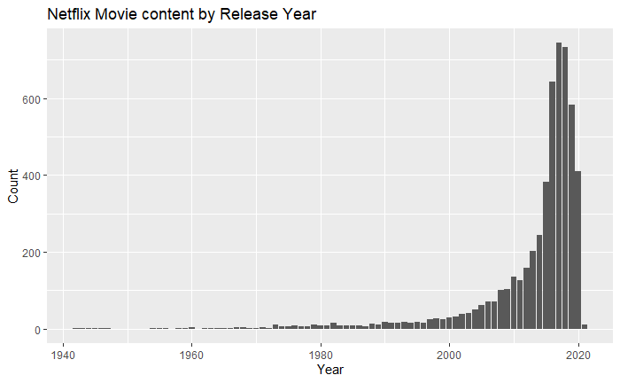

```r
netflixshows%>%
  group_by(release_year)%>%
  filter(release_year != "" |  !is.na(release_year))%>%
  filter(type == "Movie")%>%
  ggplot()+
    geom_bar(mapping = aes(
      x = release_year))+
      labs(
          title = "Netflix Movie content by Release Year",
          x = "Year",
          y = "Count"
        )
```

**Netflix TV Show content by Release Year**

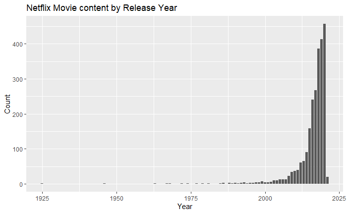

```r
netflixshows%>%
  group_by(release_year)%>%
  filter(release_year != "" |  !is.na(release_year))%>%
  filter(type == "TV Show")%>%
  ggplot()+
    geom_bar(mapping = aes(
      x = release_year))+
      labs(
          title = "Netflix Movie content by Release Year",
          x = "Year",
          y = "Count"
        )
```

### Age Rating:

Netflix rates all of their shows in a way that suggests appropriate ages see appropriate material. The graph below demonstrates the distribution between Netflix’s content and the associating Age rating.

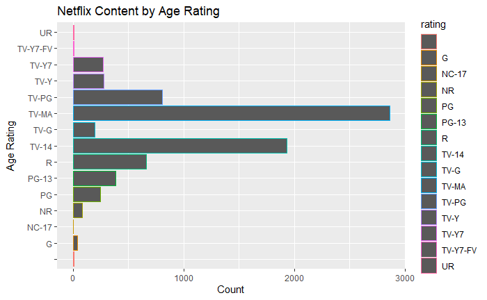

```r
netflixshows%>%
  group_by(rating)%>%
  filter(rating != "" | !is.na(rating))%>%
  ggplot()+
  geom_bar(mapping = aes(
    y = rating,
    color = rating))+
    labs(
        title = "Netflix Content by Age Rating",
        x = "Count",
        y = "Age Rating"
      )
```

```r
NA
```

### Possible questions:

1. Amount of content as a function of time released
2. Is there a relationship between the rating of a show and the year of release?
3. Is there a possible relationship of mature ratings to user scores
4. Amount of content as a function of rating level
5. Does the director have a connection to the rating popularity?
6. Is there a popular connection with the shows and development of a specific country?
7. Is it possible for other countries to catch up from the number of shows compared to the United States in the future?
8. Does a specific director boost a country’s popularity after a show’s successful launch? Possibly creation inspiration for new and upcoming directors?
9. Will the release years be more varied?